# Pharos — Adverse Drug Reaction Signal Detection

Disproportionality Analysis of OpenFDA FAERS Reports

Author

Pharos Pipeline · OpenFDA FAERS data

Published

October 19, 2026

## Introduction

Pharmacovigilance is the science of monitoring drugs for safety problems after they reach the market. Spontaneous reporting systems — where healthcare professionals and patients submit voluntary reports of suspected adverse reactions — are the primary data source for post-market surveillance. The US FDA Adverse Event Reporting System (FAERS), served via the OpenFDA API, is the largest such database, containing millions of reports submitted since 1969.

This report applies **disproportionality analysis** to a sample of FAERS data. The core question is: *does a given drug appear alongside a given adverse reaction more often than you would expect by chance, given how commonly that reaction is reported for all other drugs?* When the answer is yes — and the excess is statistically robust — that drug-reaction pair is flagged as a **safety signal** warranting further investigation. A signal is not a proven causal link; it is a statistical anomaly that prompts closer scrutiny.

## Methods

### Data source

Adverse event reports were fetched from the OpenFDA FAERS endpoint (`api.fda.gov/drug/event.json`) using the Pharos ingestion pipeline. Each report was exploded into one row per reaction, normalised to lowercase, deduplicated by safety report ID + reaction, and stored in a local SQLite database.

**Data summary**

```python
summary = pd.DataFrame({
    "Item": ["Drugs analysed", "Total AE report-rows", "Drug-reaction pairs evaluated", "Signals flagged"],
    "Value": [n_drugs, f"{n_ae_total:,}", f"{n_pairs:,}", n_flagged],
})
summary.style.hide(axis="index").set_properties(**{"text-align": "left"})
```

| Item | Value |
| --- | --- |
| Drugs analysed | 3 |
| Total AE report-rows | 34,127 |
| Drug-reaction pairs evaluated | 2,264 |
| Signals flagged | 386 |

### Drug-name canonicalisation

Reports are aggregated under a canonical generic name resolved by `pipeline.normalise.canonical`, which consults a curated alias table at `pipeline/drug_aliases.json` and falls through to `lower().strip()` for unmapped names. Coverage is deliberately narrow — roughly 30 common brand → generic mappings — and unmapped brand names remain a known weakness. RxNorm integration is deferred to V2; until then, brand/generic ambiguity is a documented limitation (see below).

### Reporting Odds Ratio (ROR)

For each drug **X** and reaction **Y**, a 2×2 contingency table is constructed:

|  | Reaction Y | Other reactions |
| --- | --- | --- |
| **Drug X** | *a* | *b* |
| **All other drugs** | *c* | *d* |

$$\text{ROR} = \frac{a/b}{c/d}$$

The 95% confidence interval uses the log-normal approximation:

$$\text{SE} = \sqrt{\frac{1}{a} + \frac{1}{b} + \frac{1}{c} + \frac{1}{d}}$$

$$\text{CI} = \exp\!\left(\ln(\text{ROR}) \pm 1.96 \cdot \text{SE}\right)$$

**Signal threshold:** ROR lower 95% CI > 1 (strict inequality), per Rothman 2004.

### Proportional Reporting Ratio (PRR)

$$\text{PRR} = \frac{a\,/\,(a+b)}{c\,/\,(c+d)}$$

The associated chi-squared statistic uses the exact Pearson formula:

$$\chi^2 = \frac{N \cdot (ad - bc)^2}{(a+b)(c+d)(a+c)(b+d)}$$

**Signal thresholds (EVANS criterion):** PRR ≥ 2 **and** *n* ≥ 3 **and** χ² ≥ 4, all inclusive, all required (Evans 2001).

### Background denominator

“All other drugs” is taken globally — every drug in `adverse_events` other than the target drug, across the full ingested date range. No stratification by ATC class, indication, or time window is applied. This is the simplest defensible choice for an MVP. Stratified analysis (Bate-style sub-group ROR) is V2.

### Zero-cell handling (Yates 0.5)

When any contingency cell is zero, the default behaviour is to apply Yates’ 0.5 continuity correction (Rothman 2004 §15) — 0.5 is added to every cell before computing — and return a finite estimate. Strict-mode callers pass `continuity_correction=False` to `analysis.disproportionality` and get `None` instead.

Two cases bypass Yates and always return `None`:

- `a + b == 0` — the drug is entirely absent from the dataset.
- `c + d == 0` — there are no comparator drugs.

`n_reports` always reflects the **observed** `a`, not the corrected value, so Yates does not promote noise into flagged signals — the EVANS `a ≥ 3` floor still gates `flag_signal`.

### Cell-inclusion floor

`compute_all_signals` skips any pair with observed `a < min_reports` (default 3) before computing anything — the EVANS-criterion floor for stable PRR estimation. This is what keeps the signal table finite on FAERS-scale data: a naïve `n_drugs × n_reactions` matrix is roughly 10⁸ cells, and the vast majority of those cells carry only one or two reports of noise.

## Results

### Flagged signals

A drug-reaction pair is flagged when **all four criteria** are simultaneously met: ROR lower CI > 1, PRR ≥ 2, n ≥ 3, χ² ≥ 4.

Table 1

| Drug | Reaction | ROR | 95% CI lower | 95% CI upper | PRR | χ² | n |
| --- | --- | --- | --- | --- | --- | --- | --- |
| ibuprofen | rheumatoid factor positive | 111.92 | 6.81 | 1840.69 | 111.66 | 53.8 | 24 |
| ibuprofen | adjustment disorder with depressed mood | 75.32 | 4.52 | 1255.59 | 75.20 | 35.5 | 16 |
| aspirin | vascular stent thrombosis | 68.32 | 4.12 | 1133.79 | 68.21 | 32.3 | 18 |
| ibuprofen | food interaction | 63.98 | 8.70 | 470.31 | 63.81 | 59.7 | 28 |
| ibuprofen | anion gap increased | 61.61 | 3.66 | 1036.47 | 61.53 | 28.7 | 13 |
| ibuprofen | prostate cancer stage iii | 61.61 | 3.66 | 1036.47 | 61.53 | 28.7 | 13 |
| ibuprofen | congenital hydronephrosis | 61.61 | 3.66 | 1036.47 | 61.53 | 28.7 | 13 |
| ibuprofen | microcytic anaemia | 61.61 | 3.66 | 1036.47 | 61.53 | 28.7 | 13 |
| ibuprofen | renal tubular dysfunction | 47.90 | 2.81 | 817.57 | 47.85 | 21.9 | 10 |
| ibuprofen | toxic epidermal necrolysis | 47.90 | 2.81 | 817.57 | 47.85 | 21.9 | 10 |
| aspirin | nasal oedema | 46.14 | 2.73 | 779.35 | 46.09 | 21.2 | 12 |
| ibuprofen | status migrainosus | 43.34 | 2.52 | 744.67 | 43.30 | 19.6 | 9 |
| ibuprofen | pyroglutamic acidosis | 43.34 | 2.52 | 744.67 | 43.30 | 19.6 | 9 |
| metformin | abdominal sepsis | 40.19 | 2.35 | 685.99 | 40.16 | 18.2 | 10 |
| metformin | vitamin b12 deficiency | 40.19 | 2.35 | 685.99 | 40.16 | 18.2 | 10 |
| ibuprofen | intervertebral disc protrusion | 38.80 | 5.16 | 291.62 | 38.74 | 34.7 | 17 |
| ibuprofen | toxic shock syndrome streptococcal | 38.77 | 2.24 | 671.81 | 38.74 | 17.4 | 8 |
| ibuprofen | scrotal abscess | 38.77 | 2.24 | 671.81 | 38.74 | 17.4 | 8 |
| ibuprofen | poisoning deliberate | 36.52 | 4.84 | 275.40 | 36.46 | 32.5 | 16 |
| metformin | ketosis | 36.36 | 2.12 | 624.83 | 36.33 | 16.3 | 9 |
| metformin | bicytopenia | 36.36 | 2.12 | 624.83 | 36.33 | 16.3 | 9 |
| metformin | wrong patient received product | 36.36 | 2.12 | 624.83 | 36.33 | 16.3 | 9 |
| aspirin | swelling of eyelid | 35.06 | 2.04 | 602.38 | 35.03 | 15.7 | 9 |
| ibuprofen | bezoar | 34.21 | 1.95 | 599.00 | 34.18 | 15.1 | 7 |
| ibuprofen | medication overuse headache | 34.21 | 1.95 | 599.00 | 34.18 | 15.1 | 7 |
| ibuprofen | gastric ileus | 34.21 | 1.95 | 599.00 | 34.18 | 15.1 | 7 |
| metformin | respiratory acidosis | 32.53 | 1.88 | 563.70 | 32.51 | 14.4 | 8 |
| metformin | spinal cord haematoma | 32.53 | 1.88 | 563.70 | 32.51 | 14.4 | 8 |
| ibuprofen | sleep disorder due to general medical condition, insomnia type | 31.95 | 4.20 | 242.98 | 31.90 | 28.0 | 14 |
| metformin | suspected suicide | 31.64 | 7.59 | 131.88 | 31.55 | 55.8 | 33 |

[output cut: 356 more lines]

### ROR distribution

The histogram below shows the distribution of ROR values across all 2264 evaluable drug-reaction pairs. Most pairs cluster near 1.0 (no disproportionality); the long right tail contains the flagged signals.

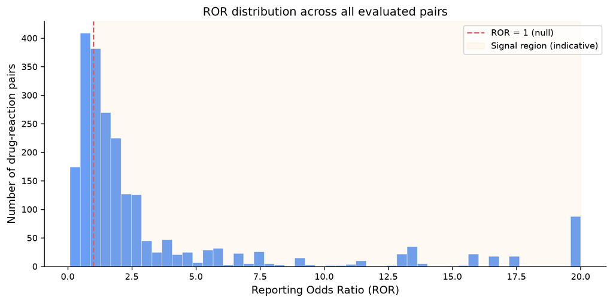

Figure 1: Distribution of ROR values across all drug-reaction pairs. Dashed line marks ROR = 1 (null). Pairs with ROR > 20 are binned together at the right edge.

### Top reactions per drug

The charts below show the ten most frequently reported adverse reactions for each drug in the current dataset (ranked by raw report count, not by signal strength).

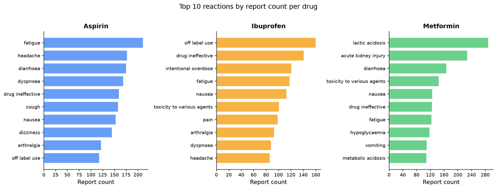

Figure 2: Top 10 adverse reactions per drug by report count.

## Limitations

FAERS is a spontaneous-reporting database. Disproportionality on FAERS is useful for **hypothesis generation** and is not causal evidence. Signals must be read with these constraints in mind:

- **Notoriety bias.** Recent media coverage inflates reporting rates; the resulting signal reflects attention, not pharmacology.
- **Indication confounding.** A drug’s indication can co-occur with the reaction independent of the drug — e.g. an anti-emetic flagged for the cancer it treats.
- **Weber effect.** Reporting peaks 1–2 years after launch and decays thereafter; early-cycle signals are not directly comparable to late-cycle ones.
- **Masking.** A common drug-event pair can suppress signal detection for related, less-reported pairs in the same comparator pool.
- **Stimulated reporting.** Litigation, regulatory letters, or social-media campaigns spike reports without any underlying epidemiological change.
- **No exposure denominator.** FAERS records report counts, not patient-exposure denominators. ROR is *reporting* odds, not incidence.
- **Brand-vs-generic ambiguity.** Mitigated by the alias table at `pipeline/drug_aliases.json` but not eliminated — unmapped brands still split signals across multiple drug-name buckets. RxNorm integration is V2.
- **Small background population (this snapshot).** The current database contains reports for only 3 drugs (Aspirin, Metformin, Ibuprofen). Disproportionality estimates are most reliable when the background population is large and diverse; signals computed against a narrow background are statistically noisier and should be interpreted cautiously. This is a property of the ingested sample, not of FAERS as a whole.
- **Unequal reporting windows (this snapshot).** Each drug is capped at roughly its most recent 10,000 report–reaction rows (one row per reaction per report), so high-volume drugs cover a shorter calendar window than low-volume ones. Current windows: Aspirin 26 May 2026 – 30 Jun 2026 (36 days); Ibuprofen 06 May 2026 – 30 Jun 2026 (56 days); Metformin 27 May 2026 – 30 Jun 2026 (35 days). The comparator pool therefore mixes reports from different periods, and any time-varying reporting (seasonal events, notoriety spikes) affects drugs unevenly. A fixed shared date window is V2.
- **MedDRA term inconsistency.** Adverse reaction terms are entered as free text and normalised to MedDRA preferred terms by OpenFDA. The same clinical event may appear under multiple terms (e.g. “bleeding” vs “haemorrhage”), leading to undercounting. No MedDRA synonym mapping has been applied in this analysis.

## References

- Rothman KJ, Lanes S, Sacks ST. *The reporting odds ratio and its advantages over the proportional reporting ratio.* Pharmacoepidemiol Drug Saf. 2004; 13: 519–523. https://doi.org/10.1002/pds.1001
- Evans SJW, Waller PC, Davis S. *Use of proportional reporting ratios (PRRs) for signal generation from spontaneous adverse drug reaction reports.* Pharmacoepidemiol Drug Saf. 2001; 10: 483–486. https://doi.org/10.1002/pds.677

## Reproducibility

This report was generated on **19 October 2026** from data stored in `db/pharos.db`. All signals are recomputed at render time from the raw `adverse_events` table — no pre-cached values are used.

To regenerate:

```bash
# 1. Refresh the database (fetches latest OpenFDA data)
python pipeline/run_refresh.py

# 2. Render this report
quarto render analysis/report.qmd
```

**Software versions** (captured at render time):

**Session info**

```python
import importlib, platform

libs = ["pandas", "sqlalchemy", "scipy", "matplotlib"]
rows = [(lib, importlib.import_module(lib).__version__) for lib in libs]
rows.insert(0, ("python", platform.python_version()))

pd.DataFrame(rows, columns=["Package", "Version"]).style.hide(axis="index")
```

| Package | Version |
| --- | --- |
| python | 3.11.17 |
| pandas | 3.0.6 |
| sqlalchemy | 2.1.5 |
| scipy | 1.17.1 |
| matplotlib | 3.11.2 |